# IODS course project

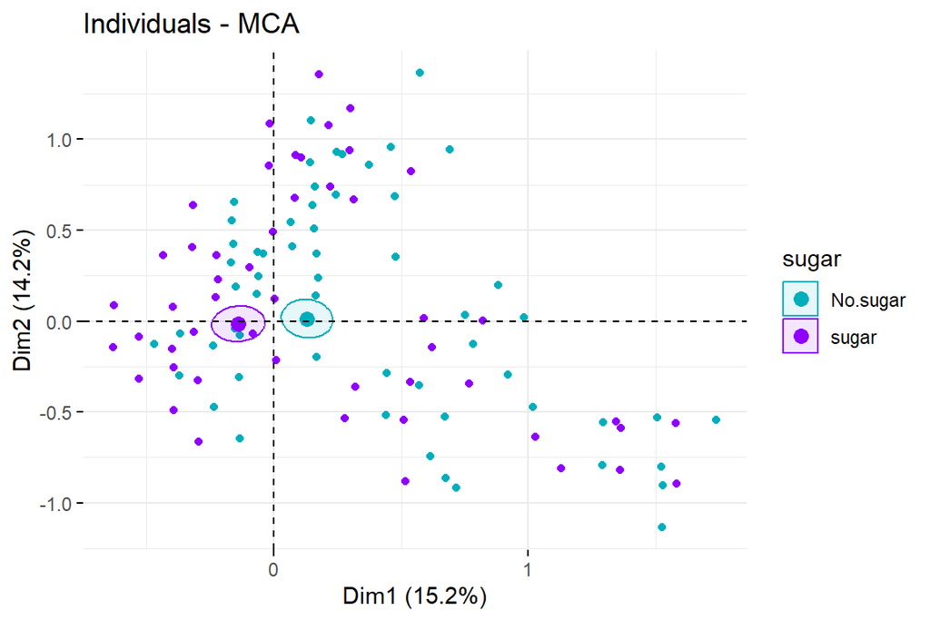

```r
fviz_mca_ind(mca,
             label = "none", # hide individual labels
             habillage = "sugar", # color by groups
             palette = c("#00AFBB", "#8f00ff"),
             addEllipses = TRUE, ellipse.type = "confidence",
             ggtheme = theme_minimal())
```

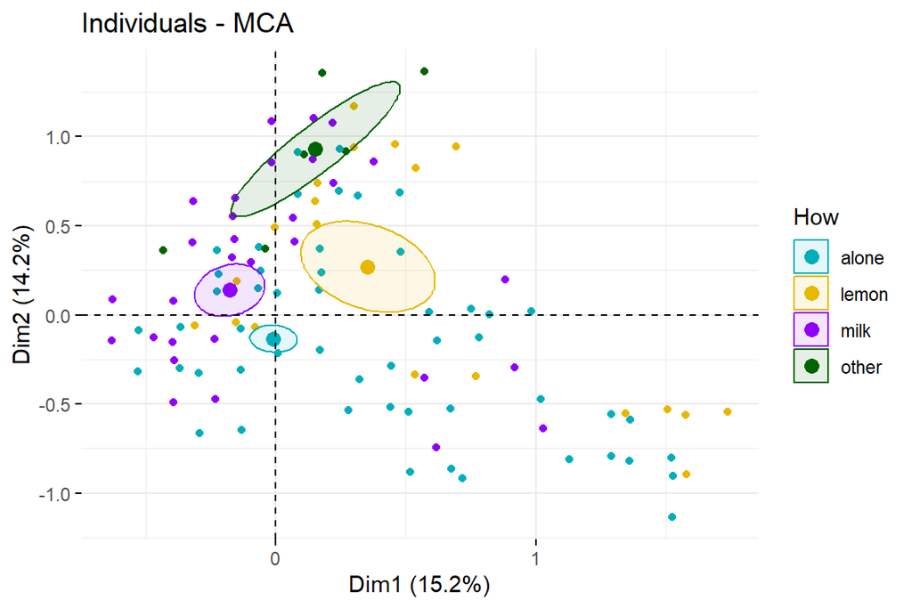

```r
fviz_mca_ind(mca,
             label = "none", # hide individual labels
             habillage = "How", # color by groups
             palette = c("#00AFBB", "#E7B800", "#8f00ff", "#006400"),
             addEllipses = TRUE, ellipse.type = "confidence",
             ggtheme = theme_minimal())
```

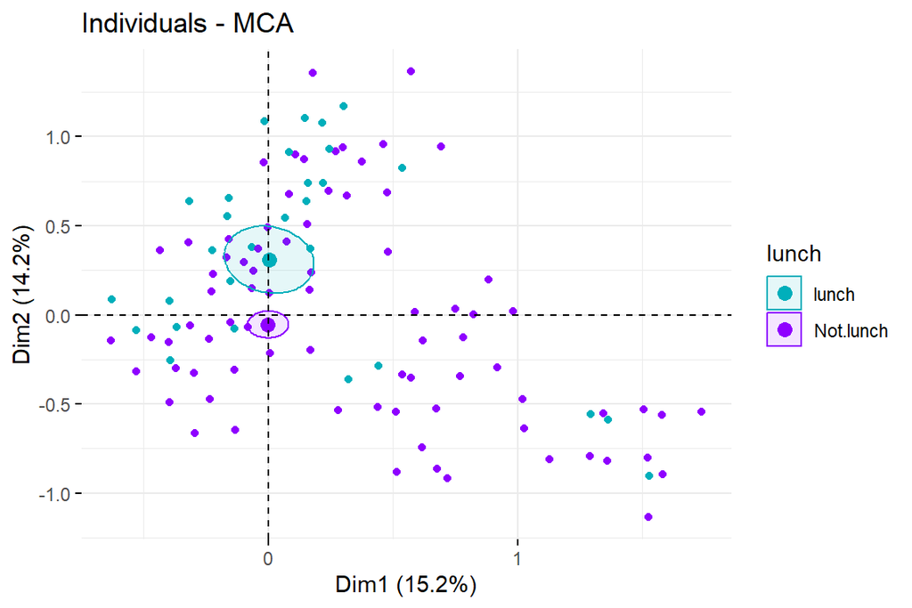

```r
fviz_mca_ind(mca,
             label = "none", # hide individual labels
             habillage = "lunch", # color by groups
             palette = c("#00AFBB", "#8f00ff"),
             addEllipses = TRUE, ellipse.type = "confidence",
             ggtheme = theme_minimal())
```

# Assignment 6. Analysis of longitudinal data

```r
#libraries
library(dplyr)
library(tidyr)
library(lme4)
```

```r
library(ggplot2)
library (ggpubr)
```

This week we are doing our analyses with two different data sets. The first, “RATS” concerns the weight of rats. The second data set, “BPRS”, deals with different treatments for psychiatric disorders.

## Analyses with the RATS data

```r
#get the data and factor it
RATS <- read.table("https://raw.githubusercontent.com/KimmoVehkalahti/MABS/master/Examples/data/rats.txt", header = TRUE, sep = '\t')
RATS$ID <- factor(RATS$ID)
RATS$Group <- factor(RATS$Group)
RATSL <- pivot_longer(RATS, cols=-c(ID,Group), names_to = "WD",values_to = "Weight")  %>%  mutate(Time = as.integer(substr(WD,3,4))) %>% arrange(Time)
```

```r
glimpse(RATSL)
```

```
## Rows: 176
## Columns: 5
## $ ID     <fct> 1, 2, 3, 4, 5, 6, 7, 8, 9, 10, 11, 12, 13, 14, 15, 16, 1, 2, 3,…
## $ Group  <fct> 1, 1, 1, 1, 1, 1, 1, 1, 2, 2, 2, 2, 3, 3, 3, 3, 1, 1, 1, 1, 1, …
## $ WD     <chr> "WD1", "WD1", "WD1", "WD1", "WD1", "WD1", "WD1", "WD1", "WD1", …
## $ Weight <int> 240, 225, 245, 260, 255, 260, 275, 245, 410, 405, 445, 555, 470…
## $ Time   <int> 1, 1, 1, 1, 1, 1, 1, 1, 1, 1, 1, 1, 1, 1, 1, 1, 8, 8, 8, 8, 8, …
```

```r
summary(RATSL)
```

```
##        ID      Group       WD                Weight           Time
##  1      : 11   1:88   Length:176         Min.   :225.0   Min.   : 1.00
##  2      : 11   2:44   Class :character   1st Qu.:267.0   1st Qu.:15.00
##  3      : 11   3:44   Mode  :character   Median :344.5   Median :36.00
##  4      : 11                             Mean   :384.5   Mean   :33.55
##  5      : 11                             3rd Qu.:511.2   3rd Qu.:50.00
##  6      : 11                             Max.   :628.0   Max.   :64.00
##  (Other):110
```

The data includes 16 rats divided into three groups that were given different diets. The rats were weighed approximately once a week over a 9-week period.

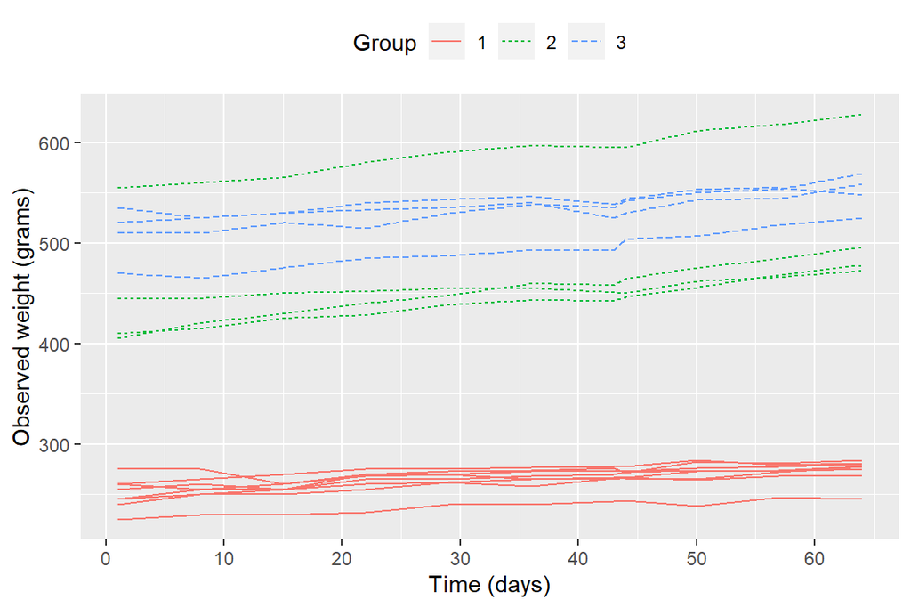

```r
RATSL <- RATSL %>%
  group_by(Time) %>%
  mutate(std_W = (Weight - mean(Weight))/sd(Weight) ) %>%
  ungroup()

ggplot(RATSL, aes(x = Time, y = Weight, group = ID)) +
  geom_line(aes(linetype = Group, col = Group)) +
  scale_x_continuous(name = "Time (days)", breaks = seq(0, 60, 10)) +
  scale_y_continuous(name = "Observed weight (grams)") +
  theme(legend.position = "top")
```

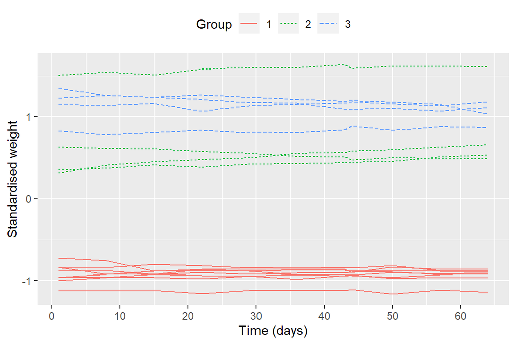

```r
ggplot(RATSL, aes(x = Time, y = std_W, group = ID)) +
  geom_line(aes(linetype = Group, col = Group)) +
  scale_x_continuous(name = "Time (days)", breaks = seq(0, 60, 10)) +
  scale_y_continuous(name = "Standardised weight") +
  theme(legend.position = "top")
```

```r
RATSS <- RATSL %>%
  group_by(Group, Time) %>%
  summarise( mean = mean(Weight), se = sd(Weight) ) %>%
  ungroup()
```

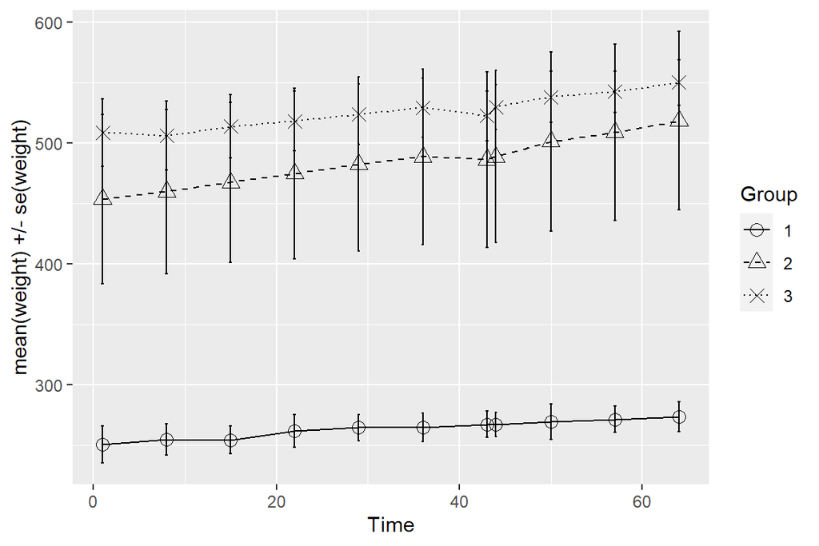

```r
#glimpse(RATSS)

ggplot(RATSS, aes(x = Time, y = mean, linetype = Group, shape = Group)) +
  geom_line() +
  scale_linetype_manual(values = c(1,2,3)) +
  geom_point(size=3) +
  scale_shape_manual(values = c(1,2,4)) +
  geom_errorbar(aes(ymin=mean-se, ymax=mean+se, linetype="1"), width=0.3) +
  theme(legend.position = "right") +
  scale_y_continuous(name = "mean(weight) +/- se(weight)")
```

```r
RATSLF <-   filter(RATSL, ID != 12)

RATSSF <- RATSLF %>%
  group_by(Group, Time) %>%
  summarise( mean = mean(Weight), se = sd(Weight) ) %>%
  ungroup()
```

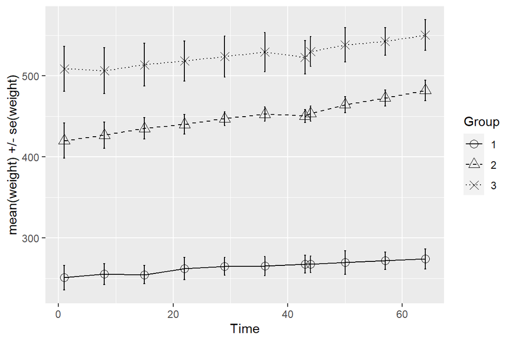

```r
ggplot(RATSSF, aes(x = Time, y = mean, linetype = Group, shape = Group)) +
  geom_line() +
  scale_linetype_manual(values = c(1,2,3)) +
  geom_point(size=3) +
  scale_shape_manual(values = c(1,2,4)) +
  geom_errorbar(aes(ymin=mean-se, ymax=mean+se, linetype="1"), width=0.3) +
  theme(legend.position = "right") +
  scale_y_continuous(name = "mean(weight) +/- se(weight)")
```

The graph above shows the development of the rats’ weight during the experiment. In addition to the mean of the groups, there are error bars present. When it comes to groups 2 and 3, their error bars overlap quite much meaning there would be no difference between the groups. However, this is probably due to a single rat being an outlier. Dropping that rat from the data and drawing a new plot with filtered data shows a bit different picture. Now the error bars do not overlap at all.

```r
RATSL64 <- RATSL %>%
  filter(Time > 1) %>%
  group_by(Group, ID) %>%
  summarise( mean=mean(Weight) ) %>%
  ungroup()
```

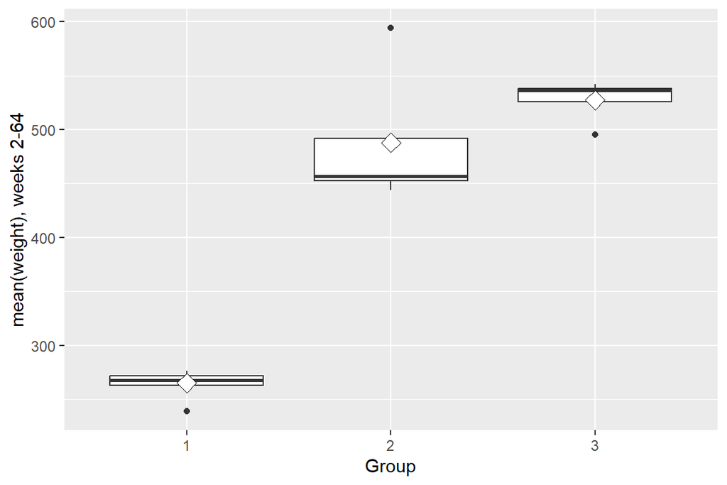

```r
# Draw a boxplot of the mean versus treatment
ggplot(RATSL64, aes(x = Group, y = mean)) +
  geom_boxplot() +
  stat_summary(fun = "mean", geom = "point", shape=23, size=4, fill = "white") +
  scale_y_continuous(name = "mean(weight), weeks 2-64")
```

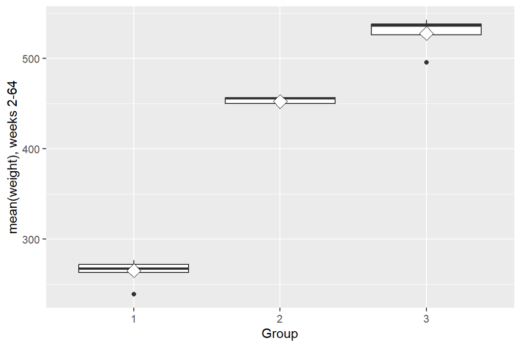

```r
RATSL64F <-   filter(RATSL64, mean < 550)

ggplot(RATSL64F, aes(x = Group, y = mean)) +
  geom_boxplot() +
  stat_summary(fun = "mean", geom = "point", shape=23, size=4, fill = "white") +
  scale_y_continuous(name = "mean(weight), weeks 2-64")
```

The boxplot graphs summarise the mean weights of the three groups in a single graph. The outlier is even clearer in this graph and removing it shows us that the variation within the groups is rather small. The first week is taken off for these graphs as it is a baseline.

```r
#t.test(mean ~ Group , data = RATSL64F, var.equal = TRUE)

t<-aov(mean ~ Group , data=RATSL64F)
t
```

```
## Call:
##    aov(formula = mean ~ Group, data = RATSL64F)
##
## Terms:
##                     Group Residuals
## Sum of Squares  207659.03   2482.94
## Deg. of Freedom         2        12
##
## Residual standard error: 14.38441
## Estimated effects may be unbalanced
```

```r
summary(t)
```

```
##             Df Sum Sq Mean Sq F value   Pr(>F)
## Group        2 207659  103830   501.8 2.72e-12 ***
## Residuals   12   2483     207
## ---
## Signif. codes:  0 '***' 0.001 '**' 0.01 '*' 0.05 '.' 0.1 ' ' 1
```

```r
RATSL64F2 <- RATSL64 %>%
  mutate(baseline = RATS$WD1)

# Fit the linear model with the mean as the response
fit <- lm(mean ~ baseline +Group  , data = RATSL64F2)

fit
```

```
##
## Call:
## lm(formula = mean ~ baseline + Group, data = RATSL64F2)
##
## Coefficients:
## (Intercept)     baseline       Group2       Group3
##     33.1637       0.9251      34.8575      23.6753
```

```r
# Compute the analysis of variance table for the fitted model with anova()
anova(fit)
```

```
## Analysis of Variance Table
##
## Response: mean
##           Df Sum Sq Mean Sq   F value   Pr(>F)
## baseline   1 253625  253625 1859.8201 1.57e-14 ***
## Group      2    879     439    3.2219  0.07586 .
## Residuals 12   1636     136
## ---
## Signif. codes:  0 '***' 0.001 '**' 0.01 '*' 0.05 '.' 0.1 ' ' 1
```

As there are three groups, I applied ANOVA to test if there is a difference between the mean weights of the groups. For the analysis, I used filtered data. ANOVA implies that there is a difference as the test is statistically significant.

The method used here is not the recommended way to deal with autocorrelated data. Linear regression still assumes the independence of the participants. The next part, on the other hand, applies a regression technique that takes into account the special nature of longitudinal data.